# Projections for Covid-19 cases in Argentina

Raphael Volz (rv@volzinnovation.com)

Last updated on 2020-11-28

**Executive Summary:** The first wave has ended in Argentina on 2020-11-16 (Day 258). We expect a total of 2,728,743 cases in the first wave of the COVID-19 pandemic in Argentina, this is an additional 1,321,466 cases compared to current case total. New cases have peeked on 2020-10-17 with 13,811 new cases. Our models assume that after end of the current wave around 8,474 new cases will appear on an average day, since SARS-CoV-2 is now endemic. Quick, effective, and differentiated mitigation measures need to be in place to prevent a new outbreak.

# 1 New Cases

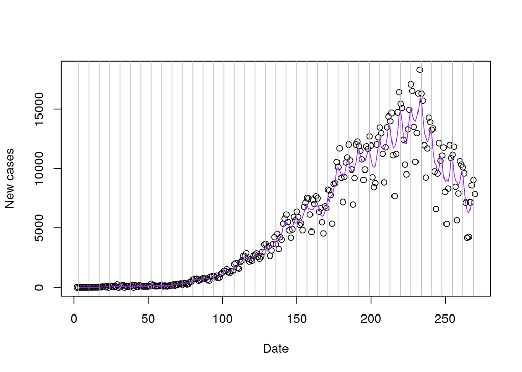

Figure 1.1: New cases and five day moving average.

## 1.1 Model for new cases (DSM)

New cases peek after a certain time of growth that follows a sigmoidal function and then recedes to a lower level as the epidemic wave fades out and enters an endemic state. This behavior can be modelled with a double-sigmoid function $f_{base}$, that is obtained by the product of two sigmoidal functions [2].

$$f_{base}(t) = \frac{1}{ 1+e^{-\alpha_{i} * (t - t_{i})} } * \frac{1}{ 1+e^{-\alpha_{d} * (t - t_{d})} }$$

This function has a maximum $f_{max} = max(f_{base}(t_{max}))$ at $t_{max}$.

The model can obtain predictions related to an observed maximum of new cases $I_{max_{d}}$ and an endemic number of daily cases $I_{final_{d}}$ as an asymptote (that is ideally 0). Let $f_{d}(t)$ be a piecewise function that switches between the growth and decay phase at $t_{max}$, such that

$$\begin{aligned}f_{d}(t) = \left\{
\begin{array}{cc}
\frac{I_{max_{d}}}{f_{max}} * f_{base}(t) & \hspace{5mm} t \leq t_{max} \\
\frac{I_{max_{d}} - I_{final_{d} }}{f_{max}} * f_{base}(t) + I_{final_{d}} & \hspace{5mm} t > t_{max} \\
\end{array} \right.
\end{aligned}$$

where $t_{i}$ is the midpoint and $\alpha_{i}$ the slope of the increase of cases and $t_{d}$ is the midpoint and $\alpha_{d}$ is the slope of the decrease in cases. $I_{max_{d}}$ the peak of new cases and $I_{final_{d}}$ the asymptotic final value of new cases at the end of the infections wave. Figure 1.2 shows the current *double-sigmoidal model* ( orange line) that is fitted for the new case time series of Argentina, where the vertical dashed line highlights the midpoint $t_i$ of the growth phase, the vertical solid line indicates the peak of new infections $t_max$ and the vertical dotted line the midpoint $t_d$ of the decay phase. The dashed horizontal line marks the estimated asymptote of endemic new cases $I_{final_{d}}$ as this infection wave ends. We pragmatically assume that the first wave ends, when 99 percent of the decrease has happened. The dashed green line marks this date.

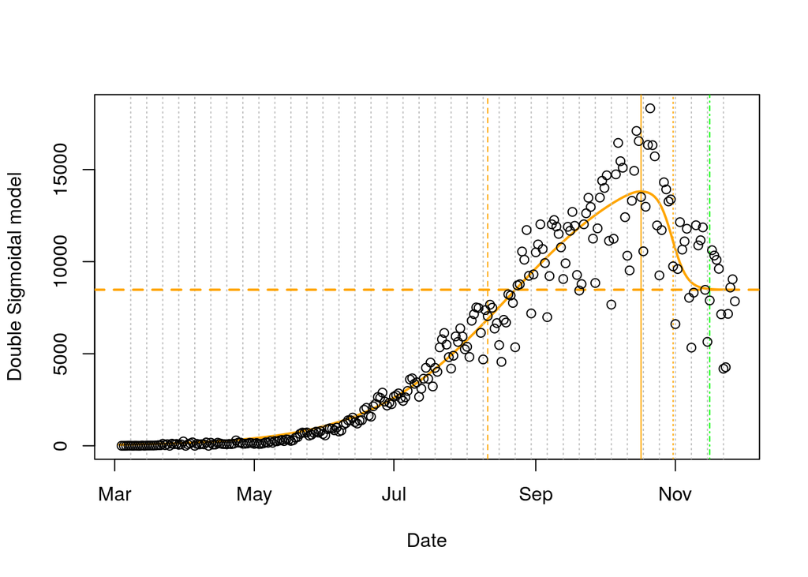

Figure 1.2: Double sigmoidal model (DSM) for new cases.

## 1.2 Reliability of the DSM

Since the model requires six parameters, it also requires more data points. Hence, it is only feasible to fit this model in later phases of the pandemic (ideally after the peak of daily infections occured) and the model is highly sensitive to new data, particularly with respect to finding the final asymptote$I_{final_{d}}$as the following comparison of the model shows. Nevertheless the model renders interesting characteristica of the past developments.

| Model for Daily Increases | Current Estimate | Last Week Estimate | Delta (absolute) |
| --- | --- | --- | --- |
| $I_{max_{d}}$ Peak new cases | 13811 | 13976 | -165 |
| $I_{final_{d}}$ Endemic new cases | 8474 | 9454 | -981 |
| $\alpha_{i}$ Slope of growth phase | 0.03 | 0.03 | 0 |
| $t_{i}$ Midpoint of growth phase | 2020-08-11 (Day 162) | 2020-08-11 (Day 162) | 0 |
| $t_{max}$ Peak day | 2020-10-17 (Day 229) | 2020-10-21 (Day 233) | -4 |
| $\alpha_{d}$ Slope of decay phase | 0.31 | 0.68 | -0.38 |
| $t_{d}$ Midpoint of decay phase | 2020-10-31 (Day 243) | 2020-10-29 (Day 241) | 2 |
| First wave ends | 2020-11-16 (Day 258) | 2020-11-16 (Day 258) | 0 |

# 2 Cumulative cases

The cumulative total of COVID-19 cases in Argentina is the number of all COVID-19 cases known up to yesterday and **includes all patients already recovered from the infection**. This corresponds to the *Infected (I)* number in the standard epidemiological SIR model. Figure 2.1 shows the data points of the time series together with a Gompertz model for the cumulative cases (red line) as well as the cumulated double-sigmoidal model (orange line). The dashed horizontal lines show the expected maximum number of cases of the Gompertz model ( the cumulated double-sigmoidal model does not have an asymptote ).

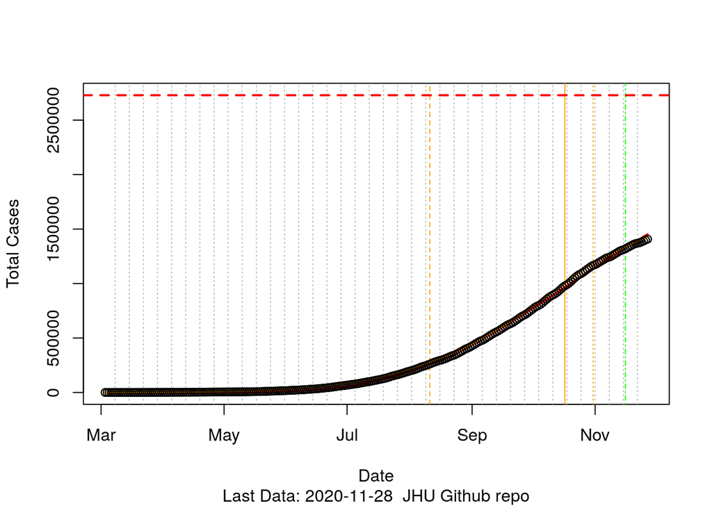

Figure 2.1: Cumulative cases with DSM and Gompertz models

## 2.1 Gompertz model for cumulative cases

The Gompertz model [3] is a sigmoid model that is often fitted to growth data, and often prefered over the standard logistic model (als called Verhulst model) due its asymetry. The Gompertz can be considered as a special case of the four parameter Richards model and is computationally easier to fit as it has one parameter less. The model is based on the cumulative distribution function $f_{c}(t)$, which is a three parameter logistic function:

$$f_{c}(t) = I_{max_{c}} * e^{ - \beta_{c} * e^{ - \alpha_{c} * t }}$$

Where the parameter $I_{max_{c}}$ is the estimated maximum number of cumulative cases (asymptote), $\beta_{c}$ inflects the curve along time, and $\alpha_{c}$ is the maximum absolute growth rate of cumulated cases.

## 2.2 Reliability of the Gompertz model

The Gompertz model change over time as new data is available. Obviously, we are interested whether the models are reliable and in particular show some convergence. When we compare the current model with the model calculated using the information that was available last week, we can again observe how the model parameters have changed.

| Parameter | Current Estimate | Last Week Estimate | Delta (absolute) |
| --- | --- | --- | --- |
| $I_{max_{c}}$ Total number of cases | 2728743 | 2982533 | -253790 |
| $\alpha_{c}$ Growth rate | 0.012 | 0.012 | 0.001 |
| $\beta_{c}$ Time shift | 17 | 16 | 1 |

# 3 Projections

## 3.1 Methodology

Putting in future dates into the current models allows to project future cases. *Note:* The actual development can differ from model predictions, for example if social distancing norms change or methods in data collection are altered. If such changes happen, a model fitted to the past is no longer valid.

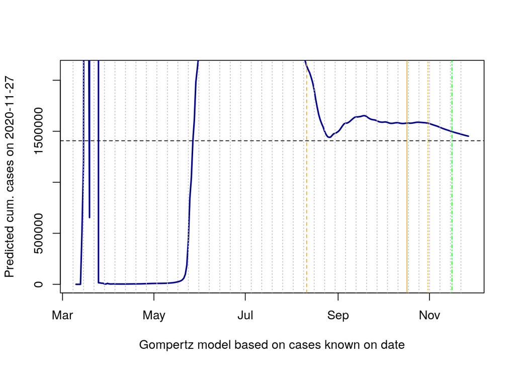

Figure 3.1: Nowcast of past models for yesterday

## 3.3 Forecast

Table 3.1 presents the predicted number of total COVID-19 cases for the upcoming week that are predicted using our models.

Table 3.1: Projected COVID-19 Cases in Argentina

| Date | Model Mean | Gompertz Model | DSM Model |
| --- | --- | --- | --- |
| 2020-11-28 | 1,439,513 | 1,463,274 | 1,415,752 |
| 2020-11-29 | 1,449,293 | 1,474,361 | 1,424,226 |
| 2020-11-30 | 1,459,048 | 1,485,395 | 1,432,700 |
| 2020-12-01 | 1,468,775 | 1,496,377 | 1,441,174 |
| 2020-12-02 | 1,478,477 | 1,507,306 | 1,449,648 |
| 2020-12-03 | 1,488,151 | 1,518,180 | 1,458,121 |
| 2020-12-04 | 1,497,798 | 1,529,000 | 1,466,595 |
| 2020-12-05 | 1,507,417 | 1,539,765 | 1,475,069 |

# 4 Discussion and outlook

As a next step data about the population and population structure could be used to compare between countries, for example to assess the effectiveness of different public policies for controlling the disease.

# 5 References

1. Johns Hopkins University, *COVID-19 global case time series (csse_covid_19_time_series)*, online https://github.com/CSSEGISandData/COVID-19/blob/master/csse_covid_19_data/csse_covid_19_time_series/ (Last accessed 2020-11-28)
2. Mehmet Caglar, Ashley Teufel, Claus Wilke, *Sicegar: R package for sigmoidal and double-sigmoidal curve fitting* in PeerJ. 2018 Jan 16;6:e4251. doi: 10.7717/peerj.4251. eCollection 2018.
3. Benjamin Gompertz, *On the nature of the function expressive of the law of human mortality and a new mode of determining the value of life contingencies*. Philosophical Transactions of the Royal Society of London : Biological Sciences. 1825, 182:5 13-85.

# A Gompertz model history

The following table states the known COVID-19 infections and duration of the pandemic in Argentina on a given day. It also states all *three parameters* of the model estimated with data available on that date and reports the root mean square error (RMSE) of the model on the available data RMSE (Training). The information made available after model creation is used as a test of the model precision on unknown data and reported as RMSE (Test). The forecast of the given model for yesterday is provided in the last column.

| Date | # Cases | # Days | I_max | beta | alpha | RMSE (Train) | RMSE (Test) | Nowcast |
| --- | --- | --- | --- | --- | --- | --- | --- | --- |
| 2020-03-10 | 17 | 8 | 389 | 6.63 | 0.10 | 2 | 582,411 | 389 |
| 2020-03-11 | 19 | 9 | 160 | 5.53 | 0.11 | 2 | 583,672 | 160 |
| 2020-03-12 | 19 | 10 | 21 | 14.53 | 0.52 | 1 | 584,881 | 21 |
| 2020-03-13 | 31 | 11 | 72 | 5.27 | 0.16 | 2 | 585,977 | 72 |
| 2020-03-14 | 34 | 12 | 547,747 | 12.64 | 0.02 | 2 | 315,938 | 531,915 |
| 2020-03-15 | 45 | 13 | 1,258,821 | 13.49 | 0.02 | 2 | 315,414 | 1,203,089 |
| 2020-03-16 | 56 | 14 | 9,722,266 | 15.51 | 0.02 | 2 | 4,118,978 | 8,597,200 |
| 2020-03-17 | 68 | 15 | 15,227,522 | 15.92 | 0.02 | 2 | 6,278,195 | 13,031,827 |
| 2020-03-18 | 79 | 16 | 4,816,313 | 14.69 | 0.02 | 2 | 1,850,262 | 4,312,811 |
| 2020-03-19 | 97 | 17 | 679,948 | 12.76 | 0.02 | 2 | 275,671 | 654,447 |
| 2020-03-20 | 128 | 18 | 786,535,579 | 19.77 | 0.01 | 3 | 173,578,770 | 431,248,190 |
| 2020-03-21 | 158 | 19 | 1,000,000,000 | 20.09 | 0.01 | 3 | 222,952,099 | 552,268,779 |
| 2020-03-22 | 266 | 20 | 1,000,000,000 | 21.25 | 0.02 | 11 | 374,762,091 | 784,668,672 |
| 2020-03-23 | 301 | 21 | 1,000,000,000 | 21.19 | 0.02 | 11 | 369,453,290 | 777,143,197 |
| 2020-03-24 | 387 | 22 | 851,050,850 | 21.05 | 0.02 | 11 | 323,312,506 | 671,200,479 |
| 2020-03-25 | 387 | 23 | 15,495 | 11.62 | 0.05 | 17 | 590,056 | 15,495 |
| 2020-03-26 | 502 | 24 | 13,927 | 11.60 | 0.05 | 16 | 592,264 | 13,927 |
| 2020-03-27 | 589 | 25 | 11,107 | 11.61 | 0.06 | 16 | 595,294 | 11,106 |
| 2020-03-28 | 690 | 26 | 10,702 | 11.62 | 0.06 | 16 | 596,775 | 10,702 |
| 2020-03-29 | 745 | 27 | 4,210 | 12.73 | 0.07 | 16 | 602,240 | 4,210 |
| 2020-03-30 | 820 | 28 | 2,853 | 14.26 | 0.09 | 17 | 604,376 | 2,853 |
| 2020-03-31 | 1,054 | 29 | 8,999 | 11.31 | 0.06 | 22 | 601,592 | 8,999 |
| 2020-04-01 | 1,054 | 30 | 4,629 | 12.48 | 0.07 | 24 | 605,717 | 4,629 |
| 2020-04-02 | 1,133 | 31 | 3,357 | 13.95 | 0.08 | 25 | 607,824 | 3,357 |
| 2020-04-03 | 1,265 | 32 | 3,346 | 13.98 | 0.08 | 24 | 609,107 | 3,346 |
| 2020-04-04 | 1,451 | 33 | 4,341 | 12.47 | 0.07 | 26 | 609,729 | 4,341 |
| 2020-04-05 | 1,451 | 34 | 3,565 | 13.64 | 0.08 | 27 | 611,536 | 3,565 |
| 2020-04-06 | 1,554 | 35 | 3,306 | 14.31 | 0.08 | 27 | 613,008 | 3,306 |
| 2020-04-07 | 1,628 | 36 | 3,095 | 15.06 | 0.09 | 28 | 614,458 | 3,095 |
| 2020-04-08 | 1,715 | 37 | 2,994 | 15.53 | 0.09 | 27 | 615,843 | 2,994 |

[output cut: 233 more lines]

# B Parameter convergence of the Gompertz model

Figures B.1 - B.3 present how the model parameters change over time as new cases are reported every day.

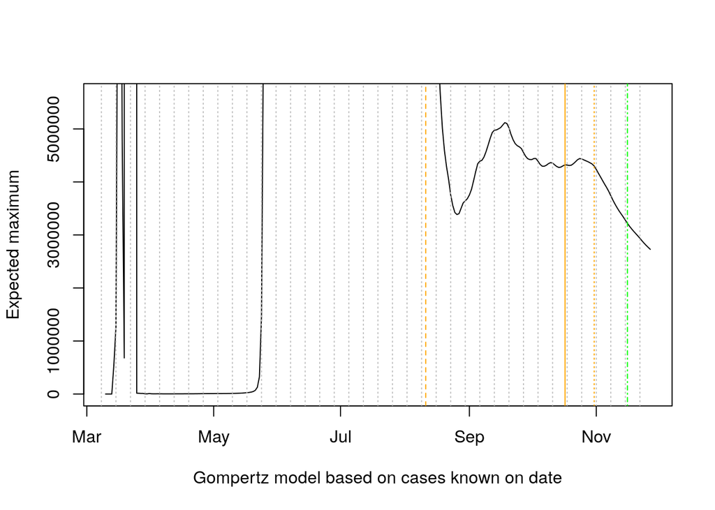

Figure B.1: Parameter evolution of expected maximum (I_max_c)

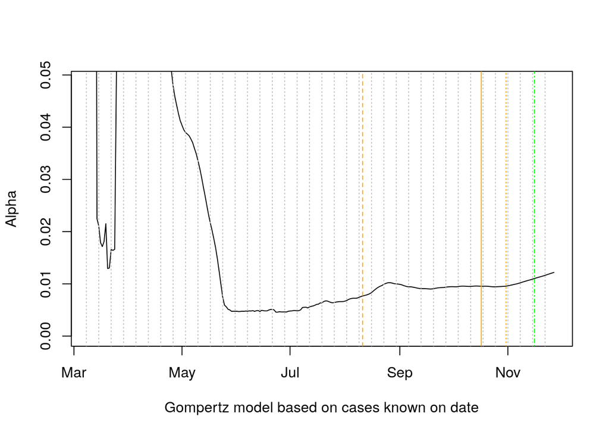

Figure B.2: Parameter evolution of growth rate (alpha_c)

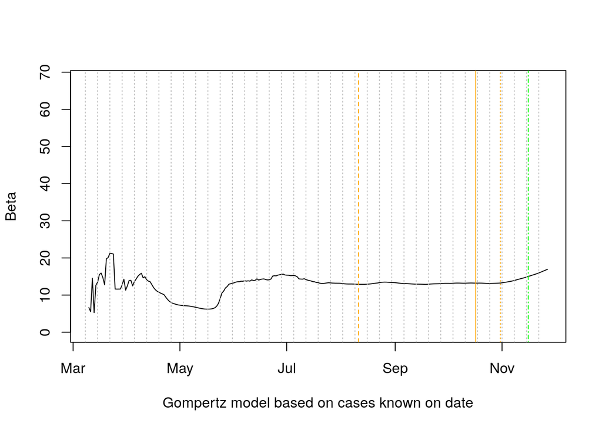

Figure B.3: Parameter evolution of time shift (beta_c)

# C Source code for model estimation

The source code for estimating the models and computing metrics, as well as generating this report can be found on [Github](https://github.com/volzinnovation/covid-19_SARS-CoV-2_corona/blob/master/src/COVID-19.rmd) and be run with the [free software environment for statistical computing and graphics R](https://www.r-project.org/) that is available for Windows, Mac and Linux.

# D Notes

This does not work for multiple waves of the infection.